# Um template de R Markdown

Tiago A. Marques e Soraia Pereira

1/27/2020

# R Markdown

Este é um documento de R Markdown, que tem a extenção “.Rmd”. O Markdown é uma sintaxe de formatação para criar facilmente documentos HTML. Na realidade, permite também criar PDFs e até documentos de Word, mas não nos vamos abordar esses formatos neste template. Estes HTML serão documentos dinâmicos, na medida em que se baseiam em dados, e quando os dados mudam, os documentos mudam também. Serão apresentados exemplos deste comportamento dinâmico baixo.

Para mais detalhes sobre o uso do R Markdown existem muito recursos online. Destes salientamos:

- http://rmarkdown.rstudio.com Analyze. Share. Reproduce. Your data tells a story. Tell it with R Markdown. Turn your analyses into high quality documents, reports, presentations and dashboards;
- https://bookdown.org/yihui/bookdown/ Como escrever livros inteiros em Markdown, bookdown: Authoring Books and Technical Documents with R Markdown por Yihui Xie;
- https://rstudio.com/wp-content/uploads/2015/02/rmarkdown-cheatsheet.pdf Cheat Sheet sobre R Markdown.

As possibilidades são imensas, mas podemos facilmente formatar o texto, e.g.:

1. itálico: *itálico*
2. bold: **bold**
3. bold e itálico: *bold*

Quando pressionamos o botão **Knit** dentro do RStudio, o “.Rmd” vai ser compilado, gerando um “.html” (html por defeito) com o mesmo nome.

Este documento que está a ler é disponibilizado como um *template*. Ao comparar este “.Rmd” com o “.html” que é criado a partir dele poderá perceber como funciona o R Markdown.

Note-se em particular que o resultado de um relatório dinâmico vai poder incluir:

- conteúdo escrito
- código R
- output de código R
- conteudo externo, e.g. figuras externas

Isto que está a ler é conteudo escrito e o código encontra-se no que se denominam *code chuncks*. O output do código só o vê depois de compilar o documento (experimente fazê-lo depois de ler isto). Para criar um *chunk* de código temos de o indicar assim:

```r
summary(beaver1)
```

```
##       day             time             temp           activ
##  Min.   :346.0   Min.   :   0.0   Min.   :36.33   Min.   :0.00000
##  1st Qu.:346.0   1st Qu.: 932.5   1st Qu.:36.76   1st Qu.:0.00000
##  Median :346.0   Median :1415.0   Median :36.87   Median :0.00000
##  Mean   :346.2   Mean   :1312.0   Mean   :36.86   Mean   :0.05263
##  3rd Qu.:346.0   3rd Qu.:1887.5   3rd Qu.:36.96   3rd Qu.:0.00000
##  Max.   :347.0   Max.   :2350.0   Max.   :37.53   Max.   :1.00000
```

Se quisermos introduzir uma figura externa, podemos fazê-lo de diversas maneiras, mas esta é a mais simples

[figure not shown]

esta figura foi retirada de um post sobre R: https://towardsdatascience.com/a-complete-guide-to-learn-r-29e691c61d1

Para incluir um gráfico de R no seu relatório dinâmico basta… criar um gráfico num *chunck*, por exemplo, assim

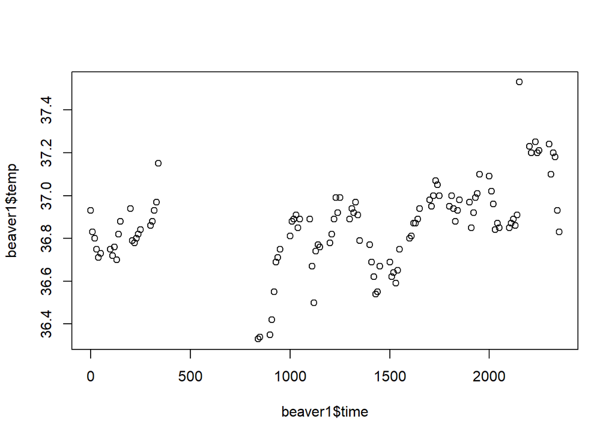

```r
plot(beaver1$time,beaver1$temp)
```

De notar que a opção `echo = FALSE` pode ser adicionada a um *chunk* para que o código não seja visualizado, mas o seu *output* sim

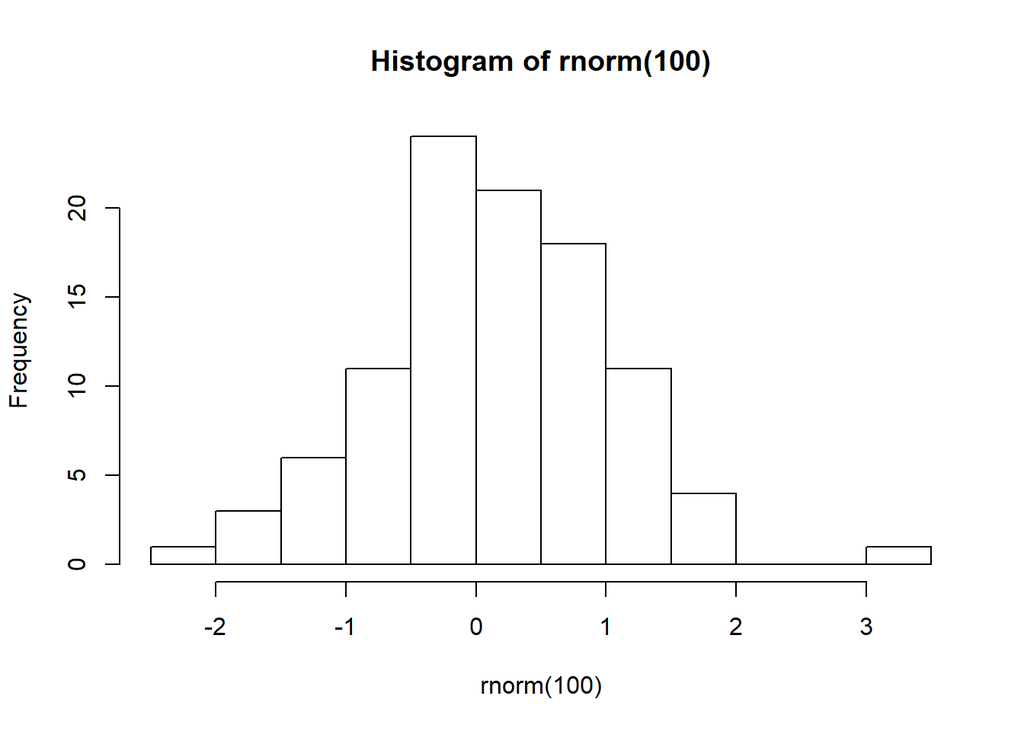

Se está a ler o “.html”, apesar de ver um gráfico acima (um histograma de 100 números pseudo-aleatórios Gaussianos), não vêmos o código que o gerou, esse só se consegue ver no “.Rmd”.

```r
set.seed(123)#use ?set.seed para descobrir o que faz esta função!
x <- rnorm(100)
```

Podemos fazer a soma destes números

```r
sum(x)
```

```
## [1] 9.040591
```

Neste momento, se alterarmos os dados que estão no objecto `x`, por exemplo substituindo o primeiro valor por um novo número

```r
x[1] <- 100
```

o mesmo código irá criar um novo *output*

```r
sum(x)
```

```
## [1] 109.6011
```

uma vez que os dados mudaram.

Agora podemos antecipar uma das grandes vantagens dos documentos dinâmicos. cada vez que os seus dados base mudarem, já não tem de repetir o seu relatório, basta recompilar o documento, e já está - tudo actualizado para a ultima versão dos dados!

Se quisermos ver código mas sem este ser executado, útil por exemplo se tivermos um erro no código, podemos usar a opção `eval = FALSE`, como por exemplo

```r
#este código tem um erro: devia ser plot e não prot!
prot(rnorm(100))
```

Note-se que o `#` tem um efeito diferente no texto corrido e nos *chunks*:

- em *chuncks*, é processado pelo R, logo é interpretado como um comentário, que não é portanto implementado (é mesmo um comentário, apenas os humanos o conseguem “ler”)
- no texto, indica um cabeçalho, de nível 1 `#`, nível 2 `##`, nível 3 `###`, e assim sucessivamente.

Assim sendo, vamos de seguida criar secções e sub-secções para ilustrar esta capacidade.

## Sugestões são bem vindas

Se tiver sugestões a fazer sobre este documento, que outras capacidades do R Markdown poderiam ser ilustradas aqui de forma simples, etc., por favor envie-nos os seus comentários.

# O meu material

A partir daqui o ficheiro é seu, poderá escrever tudo o que aprender no dia de hoje! E poderá usar este documento para novas aventuras, fazendo um *copy-paste* deste e criando novo conteudo. Aventure-se, o céu é o limite!!!

Foram criadas 3 secções para cada um dos exercícios previstos, mas na verdade, este espaço é agora seu. Construa sobre ele.

## Exercício 1

E aqui vai ficar o texto - pois vai

```r
#e aqui um code chunk!
```

## Exercício 2

E aqui vai ficar o texto

```r
#e aqui um code chunk!
```

## Exercício 3

E aqui vai ficar o texto

```r
#e aqui um code chunk!
```